# Ciência de Dados para Todos (Data Science For All) - 2018.2 - Análise da Produção Científica e Acadêmica da Universidade de Brasília - Relatório Final da Disciplina - Departamento de Ciência da Comput

## Política Social

O Programa de Pós-Graduação em Política Social (PPGPS) está vinculado ao Departamento de Serviço Social (SER), do Instituto de Ciências Humanas (IH), da Universidade de Brasília (UnB) e constitui importante espaço de formação, pesquisa e produção de conhecimento na área da Política Social. Desde 2013 está avaliado com o Conceito 6 pela CAPES. Forma anualmente mestres e doutores em Política Social e muitas teses e dissertações foram publicadas em livros e/ou artigos, e adotadas como referências para a formação em âmbito de graduação e pós-graduação. O PPGPS recebeu por três vezes o Prêmio Capes de Melhor Tese da Área de Serviço Social (2008, 2011 e 2014).

Desde seu início, o PPGPS mantém como área de concentração “Estado, Política Social e Cidadania”, e tem como eixo analítico a relação dialética e contraditória entre Estado, Classes Sociais e Direitos, mediada pelas lutas que decorrem do conflito entre capital e trabalho.

O corpo docente do Programa de Pós-Graduação em Política Social é composto atualmente por 21 professores/ as orientadores/as, sendo 18 permanentes e 3 colaboradores/as.

## O que a Organização precisa realmente alcançar?

Vários stakeholders estão envolvidos no projeto em curso, e poderíamos considerar cada um deles como distintas organizações que possuem interesses distintos e complementares. Elas são: * A Disciplina Ciência de Dados para Todos 2018.1, que quer comprovar que seus alunos dominam ferramentas e técnicas de ciência de dados, para fins de avaliação de rendimento da disciplina. * A UnB, representada pelos decanatos de pós-graduação (DPG) e de pesquisa e inovação (DPI), que querem dispor de instrumentos para realização de avaliações contínuas de suas pós-graduações. * O SNPG, que assim com o DPG e DPI, também pode se beneficiar do uso de instrumentos para realização de avaliações contínuas de suas pós-graduações. * Os interessados em melhor conhecer o que é produzido pelo Sistema Nacional de Pós-graduação, como empresas privadas, que querem desfrutar dos benefícios gerados pela ciência brasileira.

A fim de dar maior fidelidade e homogeneidade ao exercício realizado na disciplina, focaremos em atendimento aos interesses comuns das organizações DPI, DPG e CAPES, que desejam dispor de instrumentos ágeis para avaliação contínua da pós-graduação brasileira.

Com base no exposto, o objetivo do trabalho final a ser alcançado pelos produtos d emineração de dados desenvolvido pelos alunos da disciplina Ciência de Dados para Todos é produzir, tomando por base inicial os dados fornecidos pelos professores responsáveis pela disciplina, ferramentas para análise e avaliação contínuas e de baixo custo, do desempenho de um conjunto de pós-graduações que estão vinculadas a uma mesma subárea ou grupo de conhecimento. Cada área de pós-graduação apresenta suas características peculiares, assim como cada um dos programas vinculados a essas áreas. Como já informado, características peculiares de cada programa podem ser obtidas a partir de visita ao sítio da CAPES (2018).

# CRISP-DM Fase 2 - Entendimento dos Dados

Doravante, a fim de facilitar aos alunos seguirem a metodologia CRISP-DM, os nomes das seções e subseções de texto serão prefixadas com o número e nome da fase e atividade genérica do CRISP-DM. Fica facultado aos grupos seguir ou não a sequência prevista, tendo em vista que se pode retornar às fases anteriores, bem como podem haver atividades que não foram adequadas às características do problema específico sob análise.

## CRISP-DM Fase.Atividade 2.1 - Coleta inicial dos dados

Todos os arquivos com dados iniciais a seguir apresentados foram fornecidos pelos professores responsáveis pela disciplina. Os dados foram gerados no mês de maio de 2018, e compilam informações entre os anos de 2010 e 2017. Os arquivos estão no formato JSON, e seus atributos iniciais e conteúdos são apresentados a seguir.

### Perfil profissional dos docentes vinculados às pós-graduações

```r
PER_ant <- fromJSON("236.profile.json")
```

[output not shown]

### Orientações de mestrado e doutorado realizadas pelos docentes vinculados às pós-graduações

```r
ORI_ant <- fromJSON("236.advise.json")
ORI_soc <- fromJSON("328.advise.json")
ORI_pol <- fromJSON("314.advise.json")
ORI_cie <- fromJSON("255.advise.json")
file.info(ORI_ant)
```

[output not shown]

Os arquivos com sufixo “ORI” apresenta dados sobre o orientações de mestrado e doutorado feitas por todos os docentes vinculados aos respectivos programas de pós-graduação da UnB, entre 2010 e 2017. Esse arquivo foi fornecido pelos docentes responsáveis pela disciplina.

### Agrupamento dos docentes conforme áreas de atuação

```r
GRA_ant <- fromJSON("236.graph.json")
GRA_soc <- fromJSON("328.graph.json")
GRA_pol <- fromJSON("314.graph.json")
GRA_cie <- fromJSON("255.graph.json")
```

### Redes de colaboração entre docentes

Os arquivos com sufixo GRA apresentam redes de colaboração na co-autoria de artigos científicos, feitas entre os docentes vinculados a programas de pós-graduação da UnB, entre 2010 e 2017.

## CRISP-DM Fase.Atividade 2.2 - Descrição dos Dados

A leitura e manipulação dos dados é uma das principais responsáveis por uma boa análise de dados, para que possamos analisar de forma eficiente, as seguintes bibliotecas foram utilizadas:

```r
library(jsonlite)
library(listviewer)
library(readxl)
library(readr)
library(readtext)
library(ggplot2)
library(tidyverse)
```

### Descrição dos dados do perfil

O arquivo unb.perfis.json, que contém dados que caracterizam o perfil profissional de todos os docentes do grupo sob análise, podem ser lido por meio do comando seguinte.

```r
PER_ant <- fromJSON("236.profile.json")
PER_soc <- fromJSON("328.profile.json")
PER_pol <- fromJSON("314.profile.json")
PUB_cie <- fromJSON("255.publication.json")
```

A quantidade de docentes sob análise é apresentada a seguir.

```r
length(PER_ant)
```

```
[1] 26
```

```r
length(PER_soc)
```

```
[1] 27
```

```r
length(PER_pol)
```

```
[1] 21
```

```r
length(PER_cie)
```

[output not shown]

Para gerar uma apresentação inicial dos dados que estão contido nos dados de perfil dos docentes, pode-se usar a função glimpse, da biblioteca dplyr, como ilustra o código seguinte, que apresenta os atributos típicos que podem ser obtidos relativamente a um pesquisador específico, o mais antigo docente ainda em exercício na UnB a ter criado seu registro na plataforma Lattes.

```r
library(dplyr)
glimpse(PER_ant[[1]], width = 30)
```

```
List of 7
 $ nome                  : chr "Sílvia Maria Ferreira Guimarães"
 $ resumo_cv             : chr "Possui graduação em Ciências Sociais (1998), mestrado em Antropologia (2001) e doutorado em Antropologia (2005)"| __truncated__
 $ areas_de_atuacao      :'data.frame': 4 obs. of  4 variables:
  ..$ grande_area  : chr [1:4] "CIENCIAS_HUMANAS" "CIENCIAS_HUMANAS" "CIENCIAS_HUMANAS" "CIENCIAS_HUMANAS"
  ..$ area         : chr [1:4] "Antropologia" "Antropologia" "Antropologia" "Antropologia"
  ..$ sub_area     : chr [1:4] "Teoria Antropológica" "Etnologia indígena" "Antropologia da Saúde" "Saúde Coletiva"
  ..$ especialidade: chr [1:4] "" "" "" ""
 $ endereco_profissional :List of 8
  ..$ instituicao: chr "Universidade de Brasília"
  ..$ orgao      : chr "Departamento de Antropologia"
  ..$ unidade    : chr ""
  ..$ DDD        : chr "61"
  ..$ telefone   : chr "31071550"
  ..$ bairro     : chr "Asa Norte"
  ..$ cep        : chr "70910900"
  ..$ cidade     : chr "Brasília"
 $ producao_bibiografica :List of 5
  ..$ CAPITULO_DE_LIVRO                     :'data.frame':  13 obs. of  13 variables:
  .. ..$ tipo                    : chr [1:13] "Capítulo de livro publicado" "Capítulo de livro publicado" "Capítulo de livro publicado" "Capítulo de livro publicado" ...
  .. ..$ titulo_do_capitulo      : chr [1:13] "Caminhos e Territórios Guarani-Mbyá" "Metamorfoses Sanumá e a Subjetivação dos objetos" "Estados modernos, cidadania e saúde na América Latina" "Saúde, Cidadania e Pobreza entre os povos indígenas" ...
  .. ..$ titulo_do_livro         : chr [1:13] "Línguas e Culturas Tupí" "Variações interétnicas: etnicidade, conflitos e transformações" "Política, Cultura e Sociedade na América Latina: estudos interdisciplinares e comparativos" "Direitos humanos, cidadania e violência no Brasil: estudos interdisci…
  .. ..$ ano                     : chr [1:13] "2010" "2012" "2012" "2015" ...
  .. ..$ doi                     : chr [1:13] "" "" "" "" ...
  .. ..$ pais_de_publicacao      : chr [1:13] "Brasil" "Brasil" "Brasil" "Brasil" ...
  .. ..$ isbn                    : chr [1:13] "9788599944202" "9788573003628" "9788580424751" "9788544402122" ...
  .. ..$ nome_da_editora         : chr [1:13] "Curt Nimuendajú" "IBAMA/CEPPAC/IEB" "Editora CRV" "Editora CRV" ...
  .. ..$ numero_da_edicao_revisao: chr [1:13] "" "" "1" "1" ...
  .. ..$ organizadores           : chr [1:13] "CABRAL, A. S. A; RODRIGUES, A; DUARTE, F." "BAINES, S; SILVA, C; FLEISHER, D; FALEIROS, R" "Carlos Ávlia" "AVILA, C; XAVIER, L; FONSECA, V" ...
  .. ..$ paginas                 : chr [1:13] "149 - 159" "497 - 510" "133 - 150" "363 - " ...
  .. ..$ autores                 :List of 13
  .. ..$ autores-endogeno        :List of 13
  ..$ DEMAIS_TIPOS_DE_PRODUCAO_BIBLIOGRAFICA:'data.frame':  1 obs. of  9 variables:
  .. ..$ natureza          : chr "Mesa de debate"
  .. ..$ titulo            : chr "Cine diálogos socioambientais e quartas sustentáveis-sagrada terra especulada"
  .. ..$ ano               : chr "2011"
  .. ..$ pais_de_publicacao: chr "Brasil"
  .. ..$ editora           : chr ""
  .. ..$ doi               : chr ""
  .. ..$ numero_de_paginas : chr ""
```

[output cut: 110 more lines]

```
  ..$ OUTRAS_ORIENTACOES_CONCLUIDAS               :'data.frame':    66 obs. of  13 variables:
  .. ..$ natureza                   : chr [1:66] "ORIENTACAO-DE-OUTRA-NATUREZA" "ORIENTACAO-DE-OUTRA-NATUREZA" "INICIACAO_CIENTIFICA" "INICIACAO_CIENTIFICA" ...
  .. ..$ titulo                     : chr [1:66] "Práticas e noções do corpo entre terapeutas populares" "Práticas e noções do corpo entre terapeutas populares" "O sistema médico de terapeutas populares na região do DF e do entorno: o caso das rezadeiras" "O sistema médico de terapeutas populares na…
  .. ..$ ano                        : chr [1:66] "2010" "2010" "2011" "2011" ...
  .. ..$ id_lattes_aluno            : chr [1:66] "" "" "" "" ...
  .. ..$ nome_aluno                 : chr [1:66] "Grasiela dos Santos da Silva" "Elias Rodrigues Barbosa Júnior" "Nathalie Azevedo de França" "Ítala Lopes Cardoso" ...
  .. ..$ instituicao                : chr [1:66] "Universidade de Brasília" "Universidade de Brasília" "Universidade de Brasília" "Universidade de Brasília" ...
  .. ..$ curso                      : chr [1:66] "Saúde Coletiva" "Saúde Coletiva" "Saúde Coletiva" "Saúde Coletiva" ...
  .. ..$ codigo_do_curso            : chr [1:66] "90000009" "90000009" "90000009" "90000009" ...
  .. ..$ bolsa                      : chr [1:66] "SIM" "SIM" "NAO" "SIM" ...
  .. ..$ agencia_financiadora       : chr [1:66] "Decanato de Assuntos Comunitários" "Decanato de Assuntos Comunitários" "" "Conselho Nacional de Desenvolvimento Científico e Tecnológico" ...
  .. ..$ codigo_agencia_financiadora: chr [1:66] "001400000995" "001400000995" "" "002200000000" ...
  .. ..$ nome_orientadores          :List of 66
  .. ..$ id_lattes_orientadores     :List of 66
 $ senioridade           : chr "9"
```

### Descrição dos dados de orientações

```r
ORI_ant <- fromJSON("236.advise.json")
names(ORI_ant)
```

```
[1] "ORIENTACAO_EM_ANDAMENTO_DE_POS_DOUTORADO"     "ORIENTACAO_EM_ANDAMENTO_DOUTORADO"
[3] "ORIENTACAO_EM_ANDAMENTO_MESTRADO"             "ORIENTACAO_EM_ANDAMENTO_GRADUACAO"
[5] "ORIENTACAO_EM_ANDAMENTO_INICIACAO_CIENTIFICA" "ORIENTACAO_CONCLUIDA_POS_DOUTORADO"
[7] "ORIENTACAO_CONCLUIDA_DOUTORADO"               "ORIENTACAO_CONCLUIDA_MESTRADO"
[9] "OUTRAS_ORIENTACOES_CONCLUIDAS"
```

```r
names(ORI_ant$ORIENTACAO_CONCLUIDA_DOUTORADO)
```

```
[1] "2010" "2011" "2012" "2013" "2014" "2015" "2016" "2017"
```

```r
length(ORI_ant$ORIENTACAO_CONCLUIDA_DOUTORADO$`2016`$natureza)
```

```
[1] 8
```

```r
head(sort(table(ORI_ant$ORIENTACAO_CONCLUIDA_DOUTORADO$`2017`$curso), decreasing = TRUE), 10)
```

```
                                    Antropologia                              Antropologia Social
                                               3                                                3
                                         Direito            Doutorado em Antropologia - PPGAS/UnB
                                               3                                                1
                                      Literatura Programa de Pós-Graduação em Antropologia Social
                                               1                                                1
Programa de Pós Graduação Em Antropologia Social
                                               1
```

```r
head(sort(table(ORI_ant$ORIENTACAO_CONCLUIDA_MESTRADO$`2017`$curso), decreasing = TRUE), 10)
```

```
                                                               Antropologia
                                                                          9
                          Pós-Graduação. em Ciências e Tecnologias em Saúde
                                                                          4
                         Sustentabilidade junto a Povos e Terras Tradiciona
                                                                          3
                                                        Antropologia Social
                                                                          2
                                                Desenvolvimento Sustentável
                                                                          2
Mestrado Profissional em Sustentabilidade junto a Povos e Terras Tradiciona
                                                                          2
```

### Descrição dos dados de produção bibliográfica

```r
PUB_ant <- fromJSON("236.publication.json")
names(PUB_ant)
```

```
[1] "PERIODICO"                              "LIVRO"
[3] "CAPITULO_DE_LIVRO"                      "TEXTO_EM_JORNAIS"
[5] "EVENTO"                                 "ARTIGO_ACEITO"
[7] "DEMAIS_TIPOS_DE_PRODUCAO_BIBLIOGRAFICA"
```

```r
names(PUB_ant$PERIODICO$`2012`)
```

```
 [1] "natureza"         "titulo"           "periodico"        "ano"              "volume"
 [6] "issn"             "paginas"          "doi"              "autores"          "autores-endogeno"
```

```r
head(sort(table(PUB_ant$PERIODICO$`2017`$periodico), decreasing = TRUE), 10)
```

```
       INTERETHNIC@ - REVISTA DE ESTUDOS EM RELAÇÕES INTERÉTNICAS
                                                                3
                                            ANUÁRIO ANTROPOLÓGICO
                                                                2
                                          REVISTA DE ANTROPOLOGIA
                                                                2
Abya-Yala: Revista sobre Acesso à Justiça e Direitos nas Américas
                                                                1
                                           Anales de Antropología
                                                                1
                                          Análise Social (Lisboa)
                                                                1
             ANTROPOLÍTICA: REVISTA CONTEMPORÂNEA DE ANTROPOLOGIA
                                                                1
                                 Cadernos de Gênero e Diversidade
                                                                1
                                                    CADERNOS PAGU
                                                                1
                                                          DÉJÀ LU
                                                                1
```

```r
head(sort(table(PUB_ant$LIVRO$`2015`$nome_da_editora), decreasing = TRUE), 10)
```

```
                                                         Editora Universidade de Brasília
                                           1                                            1
Fondo de Cultura Económica/Colegio de México                                       Langaa
                                           1                                            1
```

## CRISP-DM Fase.Atividade 2.3 - Análise exploratória dos dados

Como já informado, a análise exploratória dos dados possibilita um entendimento mais profundo da relação estatística existente entre os dados dos *datasets* para um melhor entendimento da qualidade daqueles dados para os objetivos do projeto.

## CRISP-DM Fase.Atividade 2.4 - Verificação da qualidade dos dados.

Como já informado, a verificação da qualidade dos dados envolve responder se os dados disponíveis estão realmente completos.

As informações disponíveis são suficientes para o trabalho proposto? Neste projeto, a verificação da qualidade dos dados é responsabilidade dos alunos.

# CRISP-DM Fase 3 - **Preparação dos Dados**

Como já informado, na fase de **Preparação dos Dados** os *datasets* que serão utilizados em todo o trabalho são construídos a partir dos dados brutos. Aqui os dados são “filtrados” retirando-se partes que não interessam e selecionando-se os “campos” necessários para o trabalho de mineração.

São 5 as atividades genéricas nesta fase de preparação dos dados, a seguir divididas em subseções

## CRISP-DM Fase.Atividade 3.1 - Seleção dos dados.

Como já informado, a seleção dos dados envolve identificar quais dados, da nossa “montanha de dados”, serão realmente utilizados.

Quais variáveis dos dados brutos serão convertidas para o *dataset*?

Não é raro cometer o erro de selecionar dados para um modelo preditivo com base em uma falsa ideia de que aqueles dados contém a resposta para o modelo que se quer construir. Surge o cuidado de se separar o sinal do ruído (Silver, Nate. The Signal and the Noise: Why so many predictions fail - but some don’t. USA: The Penguin Press HC, 2012.).

## CRISP-DM Fase.Atividade 3.2 - Limpeza dos dados

## CRISP-DM Fase.Atividade 3.3 - Construção dos dados

Como já informado, a construção dos dados envolve a criação de novas variáveis a partir de outras presentes nos *datasets*.

## CRISP-DM Fase.Atividade 3.4 - Integração dos dados

Nessa fase damos ênfase na criação de datasets com diferentes tipos de dados, que foram unidos a partir dos arquivos iniciais.

## CRISP-DM Fase.Atividade 3.5 - Formatação dos dados

A formatação de dados aborda a parte de modificação e adequação dos arquivos iniciais para facilitar a análise a depender do método utilizado de mineração de dados.

# CRISP-DM Fase 4 - **Modelagem**

A modelagem de dados é referente a forma como a análise dos dados é estruturada, seja por meio de uma abordagem estátistica ou computacional, é a lógica por trás de como funciona a análise.

## CRISP-DM Fase.Atividade 4.1 - Seleção das técnicas de modelagem

Diferentes técnicas de modelagem podem ser utilizadas para analisar o conjunto de dados trabalhado, podem ser basicamente modelos que puxam mais para a análise estatística ou computacional, embora os dois sempre são necessários nessa fase.

## CRISP-DM Fase.Atividade 4.2 - Realização de testes de modelagem

Na realização de testes de modelagem diferentes modelos estatísticos ou computacionais são previamente testados e avaliados. Pode-se dividir o conjunto de dados criado anteriormente para se ter uma base de treino na construção de modelos.

# CRISP-DM Fase 5 - **Avaliação**

A avaliação do modelo e da análise de dados feita nos diz se os resultados obtidos realmente possuem sentido e se são condizentes com o esperado para o que foi feito.

## CRISP-DM Fase.Atividade 5.1 - Avaliação dos resultados

## CRISP-DM Fase.Atividade 5.2 - Revisão do processo

Caso o modelo tenha sido adequado para solucionar o problema proposto a revisão serve para garantir que o processo foi bem sucedido usando esse modelo. Bom revisar e levar em consideração também o caso de poder utilizar o modelo para outras análises.

# CRISP-DM Fase 6 - **Implantação**

A ultima fase do CRISP-DM se refere à entrega final do produto a um usuário, que passaria a utilizar esse produto regularmente. Nessa etapa o produto já está feito e pronto para ser entregue, faltando no máximo pequenos ajustes para se adequar ao que o usuário precisa. A repetição da análise deve ser garantida, visto que os dados sempre estão em constante mudança, logo a análise precisa funcionar sem que ocorra problemas com outros dados além dos disponíveis inicialmente.

## CRISP-DM Fase.Atividade 6.1 - Planejamento da transição

A parte de transição diz respeito a aplicabilidade das análises feitas aqui para o usuário final, aquele que realmente precisa dos resultados dessa análise. Para que seja garantido o bom planejamento da transição o cliente deve conseguir reproduzir a mesma análise e obter resultados satisfatórios e dentro do que havia sido pedido.

## CRISP-DM Fase.Atividade 6.2 - Planejamento do monitoramento dos produtos

O monitoramento busca a realização de atividades voltadas a garantir o correto funcionamento da análise, nem sempre o profissional reponsável pela análise de dados estará disponível para ajudar o cliente, logo o monitoramento tem como fim evitar qualquer tipo de problema que o usuário final venha a ter na hora da realização da anaálise.

## CRISP-DM Fase.Atividade 6.3 - Planejamento de manuteção

A manutenção do que foi desenvolvido dá ao usuário final a segurança que ele não ficará sem qualquer tipo de suporte, mesmo se seus dados mudarem um pouco ou algum outro pequeno problema acontecer, a análise não pode ficar inutilizada totalmente.

## CRISP-DM Fase.Atividade 6.4 - Produção do relatório final

A entrega do relatório do grupo, tomando como base este aqui, reflete a execução desta etapa.

# Visualizações

```r
ORI_ant <- ORI_ant %>%
  lapply(function(x) {
    bind_rows(x, .id = 'ano')
  }) %>%
  bind_rows(.id = 'tipo_orientacao')
ORI_ant$nome_orientadores <- as.character(ORI_ant$nome_orientadores)
ORI_pol <- ORI_pol %>%
  lapply(function(x) {
    bind_rows(x, .id = 'ano')
  }) %>%
  bind_rows(.id = 'tipo_orientacao')
ORI_pol$nome_orientadores <- as.character(ORI_pol$nome_orientadores)
ORI_cie <- ORI_cie %>%
  lapply(function(x) {
    bind_rows(x, .id = 'ano')
  }) %>%
  bind_rows(.id = 'tipo_orientacao')
ORI_cie$nome_orientadores <- as.character(ORI_cie$nome_orientadores)
```

```r
ORI_ant <- ORI_ant %>%
  mutate(programa = 'Antropologia')
ORI_pol <- ORI_pol %>%
  mutate(programa = 'Política Social')
ORI_cie <- ORI_cie %>%
  mutate(programa = 'Ciência do Comp.')
ORI <- rbind(ORI_ant, ORI_pol, ORI_cie)
```

[figure not shown]

[figure not shown]

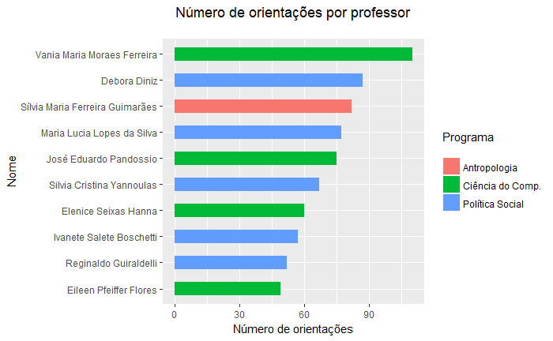

# Referências

- Azevedo, Mário Luiz Neves de, João Ferreira de Oliveira, e Afrânio Mendes Catani. “O Sistema Nacional de Pós-Graduação (SNPG) e o Plano Nacional de Educação (PNE 2014-2024): regulação, avaliação e financiamento”. Revista Brasileira de Política e Administração da Educação 32, nº 3 (2016). http://dx.doi.org/10.21573/vol32n32016.68576.
- Can, Fazli, Tansel Özyer, e Faruk Polat, orgs. State of the Art Applications of Social Network Analysis. Lecture Notes in Social Networks. Switzerland: Springer International Publishing, 2014.
- CAPES. “Documentos de Área”. CAPES.gov.br. Acessado 12 de junho de 2018. http://avaliacaoquadrienal.capes.gov.br/documentos-de-area.
- —. “Plano Nacional de Pós-Graduação - PNPG 2011/2020 Vol. 1”. Brasília - DF, dezembro de 2010. http://www.capes.gov.br/images/stories/download/Livros-PNPG-Volume-I-Mont.pdf.
- —. “Plano Nacional de Pós-Graduação - PNPG 2011/2020 Vol. 2”. Brasília - DF, dezembro de 2010. http://www.capes.gov.br/images/stories/download/PNPG_Miolo_V2.pdf.
- —. “Sucupira: coleta de dados, docentes de pós-graduação stricto sensu no Brasil 2015”. CAPES - Banco de Metadados, 16 de março de 2016. http://metadados.capes.gov.br/index.php/catalog/63.
- Chapman, Pete, Julian Clinton, Randy Kerber, Thomas Khabaza, Thomas Reinartz, Colin Shearer, e Rüdiger Wirth. “CRISP-DM 1.0: Step-by-Step Data Mining Guide”. USA: CRISP-DM Consortium, 2000. https://www.the-modeling-agency.com/crisp-dm.pdf. *DAN. Corpo Docente. Departamento de Antropologia da UnB. Disponível em: http://www.dan.unb. br/dan-corpodocente. Acesso em: 31 mai. 2018* DAN. História do DAN/UnB. Departamento de Antropologia da UnB. Disponível em: http://www. dan.unb.br/dan-historia. Acesso em: 31 mai. 2018 UnB.
- Datacamp. “Machine Learning with R (Skill Track)”. Datacamp, 2018. https://www.datacamp.com/tracks/machine-learning.
- Fernandes, Jorge H C, e Ricardo Barros Sampaio. “DataScienceForAll”. Zotero, 13 de junho de 2018. https://www.zotero.org/groups/2197167/datascienceforall.
- —. “Especificação do Trabalho Final da Disciplina de Ciência de Dados para Todos 2017.2: Estudo sobre a visibilidade internacional da produção científica das pós-graduações vinculadas às áreas de conhecimento da CAPES, na Universidade de Brasília (Comunicação Interna)”. Disciplina 116297 - Tópicos Avançados em Computadores, turma D, do semestre 2017.2, do Departamento de Ciência da Computação do Instituto de Ciências Exatas da Universidade de Brasília, 28 de novembro de 2017. https://aprender.ead.unb.br/pluginfile.php/474549/mod_resource/content/1/Estudo%20da%20Cie%CC%82ncia.pdf.
- Fernandes, Jorge H C, Ricardo Barros Sampaio, e João Ribas de Moura. “Ciência de Dados para Todos (Data Science For All) - 2018.1 - Análise da Produção Científica e Acadêmica da Universidade de Brasília - Modelo de Relatório Final da Disciplina - Departamento de Ciência da Computação da UnB”. Disciplina 116297 - Tópicos Avançados em Computadores, turma D, do semestre 2018.1, do Departamento de Ciência da Computação do Instituto de Ciências Exatas da Universidade de Brasília, 13 de junho de 2018.
- Frickel, Scott, e Kelly Moore. The New Political Sociology of Science: Institutions, Networks, and Power. Science and technology in society. USA: The University of Wisconsin Press, 2006.
- Graduate Prospects Ltd. “Job profile: Higher education lecturer”, 2018. https://www.prospects.ac.uk/job-profiles/higher-education-lecturer.
- Kalpazidou Schmidt, Evanthia, e Ebbe Krogh Graversen. “Persistent factors facilitating excellence in research environments”. Higher Education 75, nº 2 (1º de fevereiro de 2018): 341-63. https://doi.org/10.1007/s10734-017-0142-0.
- Kilduff, Martin, e Wenpin Tsai. Social Networks and Organizations. UK: Sage Publications, 2003.
- Kolaczyk, Eric D., e Gábor Csárdi. Statistical Analysis of Network Data with R. USA: Springer, 2014.
- Kuhn, Max, Jed Wing, Steve Weston, Andre Williams, Chris Keefer, Allan Engelhardt, Tony Cooper, et al. “Package ‘Caret’ - Classification and Regression Training”, 27 de maio de 2018. https://cran.r-project.org/web/packages/caret/caret.pdf.
- Leite, Fernando César Lima. “Considerações básicas sobre a Avaliação do Sistema Nacional de Pós-Graduação”. Comunicação Pessoal (slides). Universidade de Brasília, abril de 2018. https://aprender.ead.unb.br/pluginfile.php/502250/mod_resource/content/1/Considera%C3%A7%C3%B5es%20b%C3%A1sicas%20sobre%20a%20Avalia%C3%A7%C3%A3o%20do%20Sistema%20Nacional.pdf.
- Lusher, Dean, Johan Koskinen, e Garry Robins, orgs. Exponential Random Graph Models for Social Networks: Theory, methods, and applications. Structural Analysis in the Social Sciences. USA: Cambridge University Press, 2013.
- Mariscal, Gonzalo, Óscar Marbán, e Covadonga Fernández. “A survey of data mining and knowledge discovery process models and methodologies”. The Knowledge Engineering Review 25, nº 2 (2010): 137-66. https://doi.org/10.1017/S0269888910000032.
- Nery, Guilherme, Ana Paula Bragaglia, Flávia Clemente, e Suzana Barbosa. “Nem tudo parece o que é: Entenda o que é plágio”. Instituto de Arte e Comunicação Social da UFF, 2009. http://www.noticias.uff.br/arquivos/cartilha-sobre-plagio-academico.pdf.
- Nooy, Wouter de, Andrej Mrvar, e Vladimir Batagelj. Exploratory Social Network Analysis with Pajek. Structural Analysis in the Social Sciences. USA: Routldge, 2005.
- Pátaro, Cristina Saitê de Oliveira, e Frank Antonio Mezzomo. “Sistema Nacional de Pós-Graduação no Brasil: estrutura, resultados e desafios para política de Estado - Lívio Amaral”. Revista Educação e Linguagens 2, nº 3 (julho de 2013): 11-17.
- Schwartzman, Simon. “A Ciência da Ciência”. Ciência Hoje 2, nº 11 (março de 1984): 54-59.
- Silver, Nate. The Signal and the Noise: Why so many predictions fail - but some don’t. USA: The Penguin Press HC, 2012. *UNB. História. UnB. Disponível em: https://www.unb.br/a-unb/historia. Acesso em: 31 mai. 2018
- Vicari, Donatella, Akinori Okada, Giancarlo Ragozini, e Claus Wiehs. Analysis and Modeling of Complex Data in Behavioral and Social Sciences. Studies in Classifi cation, Data Analysis, and Knowledge Organization. Switzerland: Springer, 2014.
- Wickham, Hadley, e Garrett Grolemund. R for Data Science: Import, Tidy, Transform, Visualize, and Model Data. USA: O’Reilly, 2016.